# Lab 1: Motor Trend Cars

## Overview

In this lab, we will examine the Motor Trend Cars data set.

The data was extracted from the 1974 Motor Trend US magazine, and comprises fuel consumption and 10 aspects of automobile design and performance for 32 automobiles (1973–74 models).

| Variable | Description |
| --- | --- |
| mpg | Miles/(US) Gallon |
| cyl | Number of Cylinders |
| disp | Displacement (cu.in.) |
| hp | Gross horsepower |
| wt | Weight (lb/1000) |
| qsec | 1/4 mile time |
| vs | V or Straight Configuration Engine |
| am | Transmission Type (auto/manual) |

## Load the Data in StatCrunch

A Tab Separated File (.tsv) containing the data can be found here:

http://stat.wvu.edu/~draffle/111/week1/lab1/mtcars2.tsv

1. In StatCrunch, use the menus `Data` $\to$ `Load` $\to$ `From File` $\to$ `On the web`.
2. Copy and Paste the address given above into `WWW Address`
3. Click `Load File` at the bottom of the page.

## Complete the following problems on a separate piece of paper.

Hand in your answers at the end of lab – make sure to include you name and the lab number. Instructions are included for making graphs and finding the necessary statistics for each problem.

Each question will be worth two points, and you can receive partial credit for incorrect answers if your process was correct.

Write your final answer as a sentence and include all steps you used to get there, otherwise you will receive partial credit.

### 1.) List each variable and its type (categorical/quantitative).

```r
mtcars2 <- read.table("mtcars2.tsv", header = T, sep = "\t")
colnames(mtcars2)
```

```
## [1] "car"  "mpg"  "cyl"  "disp" "hp"   "wt"   "qsec" "vs"   "am"
```

### 2.) Report the Frequency and Relative Frequency Tables of `cyl`. Describe the distribution.

```r
table(mtcars2$cyl)
```

```
##
##  4  6  8
## 11  7 14
```

```r
table(mtcars2$cyl)/nrow(mtcars2)*100
```

```
##
##      4      6      8
## 34.375 21.875 43.750
```

### 3.) Sketch a Bar Plot of `am`. Which Transmission type is more common?

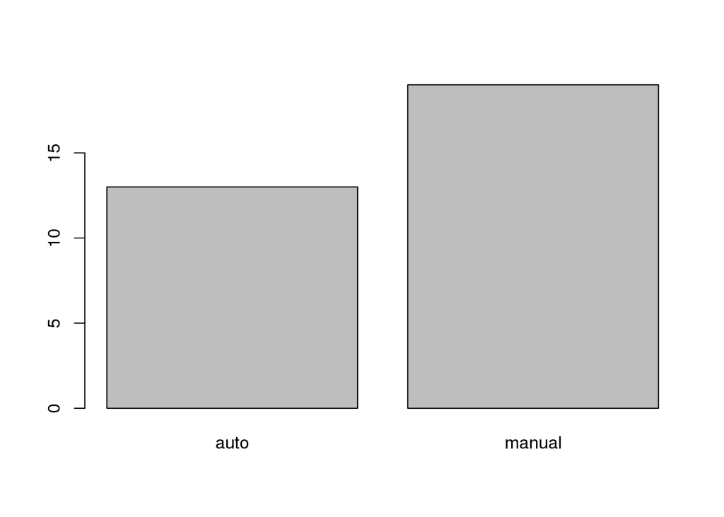

```r
plot(factor(mtcars2$am))
```

### 4.) Make a Histogram of `hp` (you do not need to sketch it). Describe the shape of the distribution.

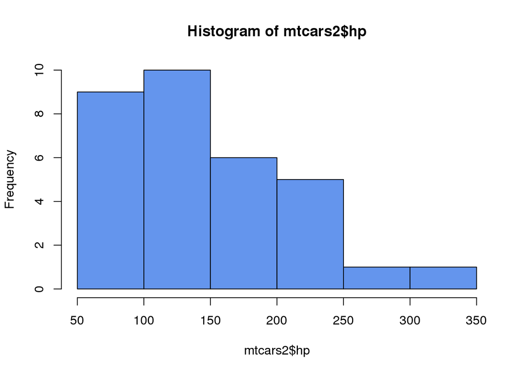

```r
hist(mtcars2$hp, col = "cornflowerblue")
```

### 5.) Which Measures of Center are better for `hp`? Report them.

```r
summary(mtcars2$hp)
```

```
##    Min. 1st Qu.  Median    Mean 3rd Qu.    Max.
##    52.0    96.5   123.0   146.7   180.0   335.0
```

### 6.) Sketch a Side-by-Side Boxplot of `hp` grouped by `am`. Describe the differences in the distributions.

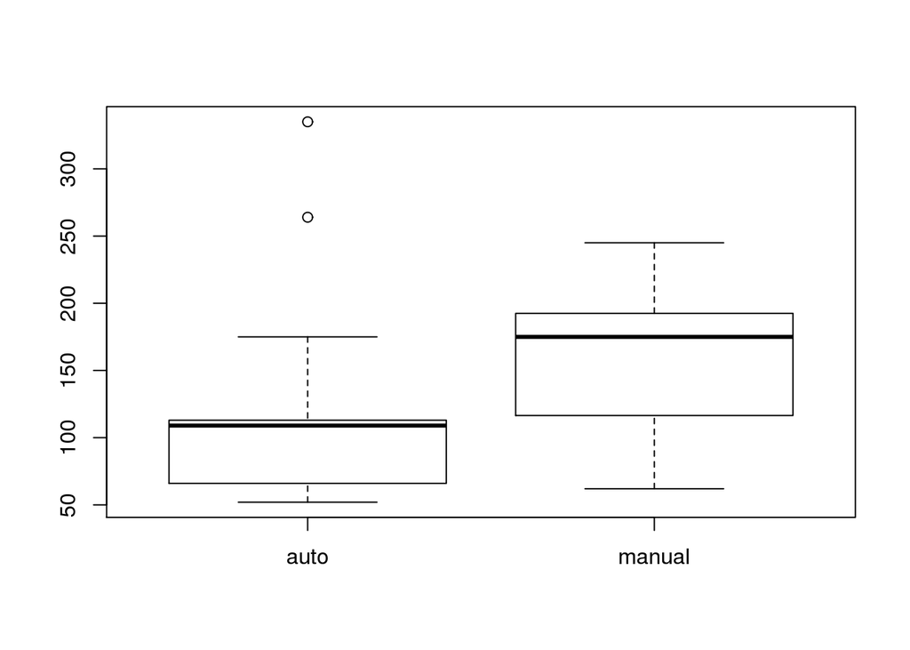

```r
boxplot(hp ~ am, mtcars2)
```

### 7.) Sketch the QQ Plot of `mpg`. Is the distribution approximately Normal?

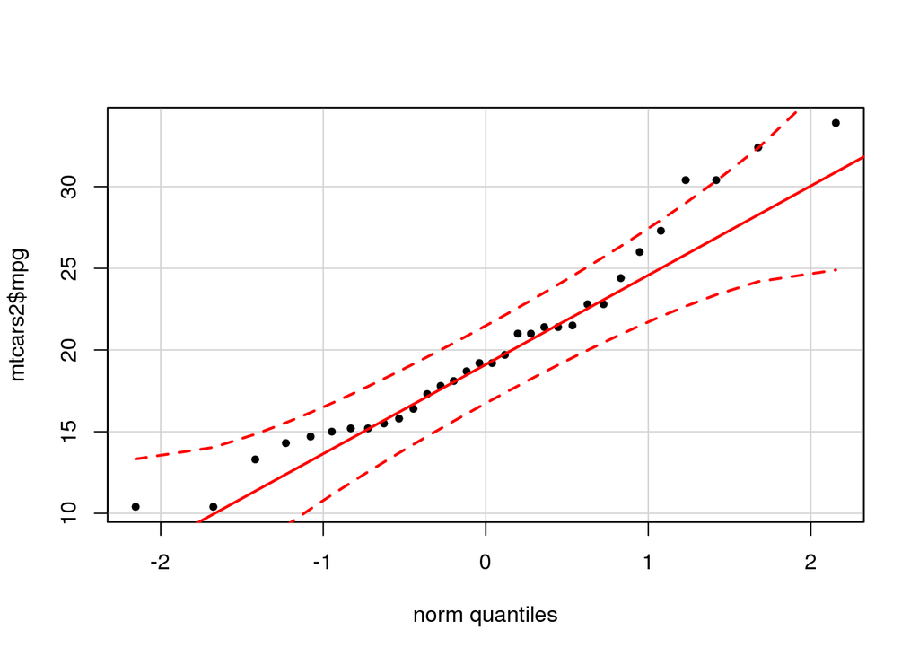

```r
library(car)
qqPlot(mtcars2$mpg,, pch = 20)
```

### 8.) If a certain car had a fuel efficiency of 22 MPG, would it be more rare for an automatic or a manual car? Show your work.

```r
by(mtcars2, mtcars2$am, function(tr) round(data.frame(mean = mean(tr$mpg), sd = sd(tr$mpg)), 2))
```

```
## mtcars2$am: auto
##    mean   sd
## 1 24.39 6.17
## --------------------------------------------------------
## mtcars2$am: manual
##    mean   sd
## 1 17.15 3.83
```

```r
(22 - 24.39)/6.17
```

```
## [1] -0.3873582
```

```r
(22 - 17.15)/3.83
```

```
## [1] 1.266319
```

### 9.) Assume that `MPG` $\sim N(\mu = 20, \sigma = 6)$. What is the 90% percentile for the `MPG` of all cars?

I.e., if $P(MPG \le x) = 0.9$, what is $x$?

```r
qnorm(.9, 20, 6)
```

```
## [1] 27.68931
```

```r
qnorm(c(.25, .75), 17.85, 1.79)
```

```
## [1] 16.64266 19.05734
```